# AK - Course Project -1

## Setting

Let’s make sure settings are correct we bore we proceed with the project.

```r
knitr::opts_chunk$set(echo = TRUE)
```

## Loading and preprocessing the data

Let’s load data file into R and see how first ten rows look like.

```r
mydata<-read.csv("activity.csv",header = TRUE,sep = ",")
head(mydata,10)
```

```
##    steps       date interval
## 1     NA 2012-10-01        0
## 2     NA 2012-10-01        5
## 3     NA 2012-10-01       10
## 4     NA 2012-10-01       15
## 5     NA 2012-10-01       20
## 6     NA 2012-10-01       25
## 7     NA 2012-10-01       30
## 8     NA 2012-10-01       35
## 9     NA 2012-10-01       40
## 10    NA 2012-10-01       45
```

## What is mean total number of steps taken per day?

### Ignoring missing values, calculate the total number of steps taken per day.

Let’s see how first ten rows look like.

```r
grouped_mydata<-aggregate(mydata$steps,by=list(date=mydata$date),FUN=sum,na.rm=TRUE)
head(grouped_mydata,10)
```

```
##          date     x
## 1  2012-10-01     0
## 2  2012-10-02   126
## 3  2012-10-03 11352
## 4  2012-10-04 12116
## 5  2012-10-05 13294
## 6  2012-10-06 15420
## 7  2012-10-07 11015
## 8  2012-10-08     0
## 9  2012-10-09 12811
## 10 2012-10-10  9900
```

## Make a histogram of the total number of steps taken each day

Here is a histogram:

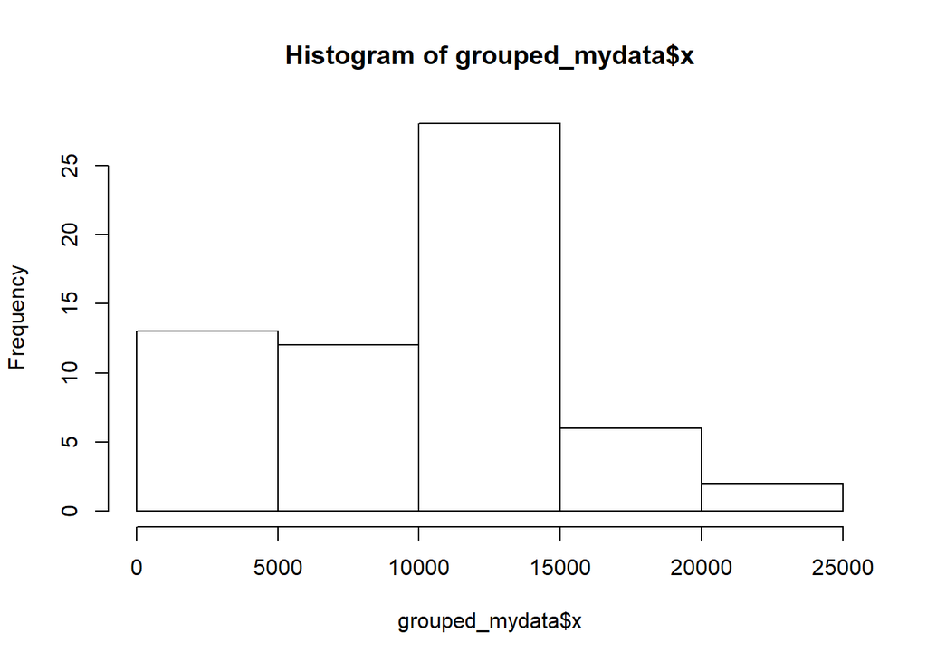

```r
hist(grouped_mydata$x)
```

## Calculate and report the mean and median of the total number of steps taken per day

```r
steps_mean<-(mean(grouped_mydata$x,na.rm = TRUE))
steps_mean_round<- format (steps_mean,digits=5)
```

```r
steps_median<-(median(grouped_mydata$x, na.rm = TRUE))
```

Mean total number of steps taken per day is 9354.2

Median total number of steps taken per day is 10395

## What is the average daily activity pattern?

Let’s re-group our original data file and see how top ten row look like:

```r
grouped_mydata_time<-aggregate(mydata$steps,by=list(interval=mydata$interval),FUN= mean, na.rm=TRUE)
head(grouped_mydata_time,10)
```

```
##    interval         x
## 1         0 1.7169811
## 2         5 0.3396226
## 3        10 0.1320755
## 4        15 0.1509434
## 5        20 0.0754717
## 6        25 2.0943396
## 7        30 0.5283019
## 8        35 0.8679245
## 9        40 0.0000000
## 10       45 1.4716981
```

## Make a time series plot of the 5-minute interval (x-axis) and the average number of steps taken, averaged across all days (y-axis)

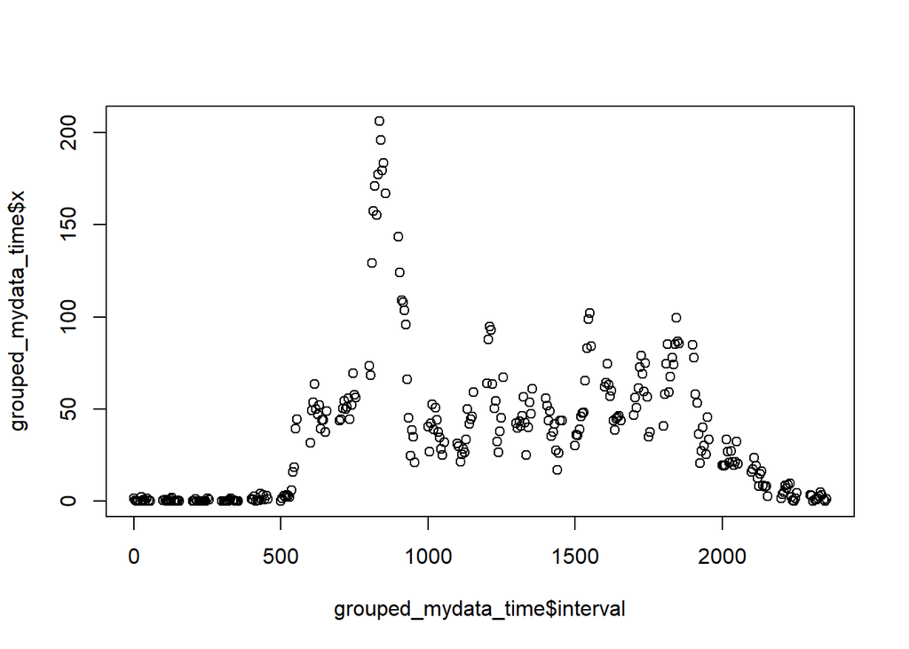

```r
plot(grouped_mydata_time$interval,grouped_mydata_time$x)
```

## Which 5-minute interval, on average across all the days in the dataset, contains the maximum number of steps?

```r
grouped_mydata_time[which.max(grouped_mydata_time$x),]
GMT<-grouped_mydata_time[which.max(grouped_mydata_time$x),]
GMT_I<-GMT[1,1]
GMT_x<-round(GMT[1,2],digits = 2)
```

[output not shown]

Interval 835 contains max number of steps - 206.17.

## Calculate and report the total number of missing values in the dataset (i.e. the total number of rows with NAs)

```r
count_NA<-sum(is.na(mydata$steps))
count_NA
```

[output not shown]

**Total number of rows with NAs is 2304.**

## Filling in all of the missing values in the dataset.

I’m agoing to use the mean for that 5-minute interval.

Let’s make sure data in the main data file is sorted first by date and then by interval.

```r
neworder<-mydata[order(mydata[,2],mydata[,3]),]
head(neworder,10)
```

```
##    steps       date interval
## 1     NA 2012-10-01        0
## 2     NA 2012-10-01        5
## 3     NA 2012-10-01       10
## 4     NA 2012-10-01       15
## 5     NA 2012-10-01       20
## 6     NA 2012-10-01       25
## 7     NA 2012-10-01       30
## 8     NA 2012-10-01       35
## 9     NA 2012-10-01       40
## 10    NA 2012-10-01       45
```

Now, let’s make sure that file contains averages by intervals is sorted by intervals.

```r
neworder2<-grouped_mydata_time[order(grouped_mydata_time[,1],grouped_mydata_time[,2]),]
head(neworder2,10)
```

```
##    interval         x
## 1         0 1.7169811
## 2         5 0.3396226
## 3        10 0.1320755
## 4        15 0.1509434
## 5        20 0.0754717
## 6        25 2.0943396
## 7        30 0.5283019
## 8        35 0.8679245
## 9        40 0.0000000
## 10       45 1.4716981
```

Let’s merger these two correctly ordered files:

```r
merger_data<-merge(neworder,neworder2)
head(merger_data)
```

```
##   interval steps       date        x
## 1        0    NA 2012-10-01 1.716981
## 2        0     0 2012-11-23 1.716981
## 3        0     0 2012-10-28 1.716981
## 4        0     0 2012-11-06 1.716981
## 5        0     0 2012-11-24 1.716981
## 6        0     0 2012-11-15 1.716981
```

Let’s just check dimentions of the new merged file:

```r
dim(neworder)
```

```
## [1] 17568     3
```

```r
dim(neworder2)
```

```
## [1] 288   2
```

```r
dim(merger_data)
```

```
## [1] 17568     4
```

Let’s re-order these data my date and interval

```r
neworder3<-merger_data[order(merger_data[,3],merger_data[,1]),]
head(neworder3)
```

```
##     interval steps       date         x
## 1          0    NA 2012-10-01 1.7169811
## 63         5    NA 2012-10-01 0.3396226
## 128       10    NA 2012-10-01 0.1320755
## 205       15    NA 2012-10-01 0.1509434
## 264       20    NA 2012-10-01 0.0754717
## 327       25    NA 2012-10-01 2.0943396
```

Finally, let’s replace all NAs with data from x column.

**So, the logic is if the data is not available for a particular date and particular interval, we will use two months average (x) for this interval as approximation.**

```r
neworder3$steps[is.na(neworder3$steps)]<-neworder3$x
head(neworder3)
```

```
##     interval     steps       date         x
## 1          0 1.7169811 2012-10-01 1.7169811
## 63         5 0.3396226 2012-10-01 0.3396226
## 128       10 0.1320755 2012-10-01 0.1320755
## 205       15 0.1509434 2012-10-01 0.1509434
## 264       20 0.0754717 2012-10-01 0.0754717
## 327       25 2.0943396 2012-10-01 2.0943396
```

## Creating new data set

Now, I will create a new dataset that is equal to the original dataset but with the missing data filled in. Let’s take a look at first ten records:

```r
new_data_set<-data.frame(neworder3$steps,neworder3$date,neworder3$interval)
names(new_data_set)<-c("steps","date","interval")
head(new_data_set,10)
```

```
##        steps       date interval
## 1  1.7169811 2012-10-01        0
## 2  0.3396226 2012-10-01        5
## 3  0.1320755 2012-10-01       10
## 4  0.1509434 2012-10-01       15
## 5  0.0754717 2012-10-01       20
## 6  2.0943396 2012-10-01       25
## 7  0.5283019 2012-10-01       30
## 8  0.8679245 2012-10-01       35
## 9  0.0000000 2012-10-01       40
## 10 1.4716981 2012-10-01       45
```

## Calculating new numbers and making new histogram.

Here is a histogram of the total number of steps taken each day.

```r
grouped_new_data_set<-aggregate(new_data_set$steps,by=list(date=new_data_set$date),FUN=sum)
head(grouped_new_data_set,10)
```

```
##          date        x
## 1  2012-10-01 10766.19
## 2  2012-10-02   126.00
## 3  2012-10-03 11352.00
## 4  2012-10-04 12116.00
## 5  2012-10-05 13294.00
## 6  2012-10-06 15420.00
## 7  2012-10-07 11015.00
## 8  2012-10-08 10766.19
## 9  2012-10-09 12811.00
## 10 2012-10-10  9900.00
```

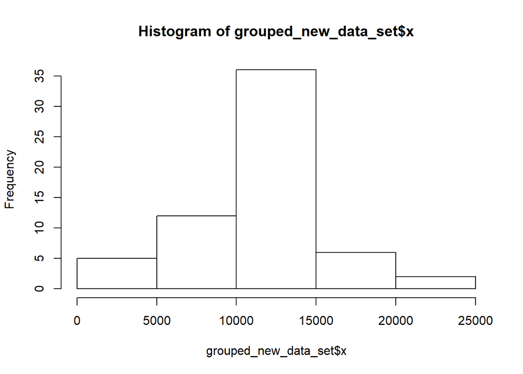

```r
hist(grouped_new_data_set$x)
```

Here I re-calculate and report the mean and median total number of steps taken per day.

```r
steps_mean_nona<-(mean(grouped_new_data_set$x))
steps_mean_nona_round<- format (steps_mean_nona,digits=5)
steps_mean_nona_round
```

```
## [1] "10766"
```

```r
steps_median_nona<-(median(grouped_new_data_set$x))
steps_median_nona_round<- format (steps_median_nona,digits=5)
steps_median_nona_round
```

```
## [1] "10766"
```

Mean total number of steps taken per day is 10766 vs.9354.2 before NAs were removed.

Median total number of steps taken per day is 10766 vs. 10395 before NAs were removed.

## Are there differences in activity patterns between weekdays and weekends?

I will creating a new factor variable in the dataset with two levels - “weekday” and “weekend” indicating whether a given date is a weekday or weekend day.

```r
new_data_set$weekdays<-weekdays(as.Date(new_data_set$date))
head(new_data_set,10)
```

```
##        steps       date interval weekdays
## 1  1.7169811 2012-10-01        0   Monday
## 2  0.3396226 2012-10-01        5   Monday
## 3  0.1320755 2012-10-01       10   Monday
## 4  0.1509434 2012-10-01       15   Monday
## 5  0.0754717 2012-10-01       20   Monday
## 6  2.0943396 2012-10-01       25   Monday
## 7  0.5283019 2012-10-01       30   Monday
## 8  0.8679245 2012-10-01       35   Monday
## 9  0.0000000 2012-10-01       40   Monday
## 10 1.4716981 2012-10-01       45   Monday
```

Instead of displaying days of the week, I want to see “Weekend” and “Weekday” in the column

```r
weekdays = c ("Monday","Tuesday", "Wednesday","Thursday","Friday", "Saturday", "Sunday")
DN = c(1,2,3,4,5,6,7)
Weeks=data.frame(weekdays,DN)
head(Weeks)
```

```
##    weekdays DN
## 1    Monday  1
## 2   Tuesday  2
## 3 Wednesday  3
## 4  Thursday  4
## 5    Friday  5
## 6  Saturday  6
```

```r
merger_day<-merge(new_data_set,Weeks)
head(merger_day)
```

```
##   weekdays steps       date interval DN
## 1   Friday     0 2012-10-05     2220  5
## 2   Friday     0 2012-11-16      430  5
## 3   Friday     0 2012-10-05     2235  5
## 4   Friday     0 2012-11-16      435  5
## 5   Friday     0 2012-10-05     2315  5
## 6   Friday     0 2012-11-16      445  5
```

```r
merger_day<-merger_day[order(merger_day$date,merger_day$interval),]
head(merger_day)
```

```
##      weekdays     steps       date interval DN
## 2593   Monday 1.7169811 2012-10-01        0  1
## 2594   Monday 0.3396226 2012-10-01        5  1
## 2595   Monday 0.1320755 2012-10-01       10  1
## 2596   Monday 0.1509434 2012-10-01       15  1
## 2597   Monday 0.0754717 2012-10-01       20  1
## 2598   Monday 2.0943396 2012-10-01       25  1
```

```r
merger_day$Weekend<-ifelse(merger_day$DN > 5,"Weekend","Weekday")

head(merger_day)
```

```
##      weekdays     steps       date interval DN Weekend
## 2593   Monday 1.7169811 2012-10-01        0  1 Weekday
## 2594   Monday 0.3396226 2012-10-01        5  1 Weekday
## 2595   Monday 0.1320755 2012-10-01       10  1 Weekday
## 2596   Monday 0.1509434 2012-10-01       15  1 Weekday
## 2597   Monday 0.0754717 2012-10-01       20  1 Weekday
## 2598   Monday 2.0943396 2012-10-01       25  1 Weekday
```

```r
merger_day<-merger_day[c(2,3,4,6)]
head(merger_day)
```

```
##          steps       date interval Weekend
## 2593 1.7169811 2012-10-01        0 Weekday
## 2594 0.3396226 2012-10-01        5 Weekday
## 2595 0.1320755 2012-10-01       10 Weekday
## 2596 0.1509434 2012-10-01       15 Weekday
## 2597 0.0754717 2012-10-01       20 Weekday
## 2598 2.0943396 2012-10-01       25 Weekday
```

## Making a new plot

**Weekend portion**

```r
grouped_by_w<-subset(merger_day,merger_day$Weekend == "Weekend")
head (grouped_by_w,10)
```

```
##      steps       date interval Weekend
## 5326     0 2012-10-06        0 Weekend
## 5327     0 2012-10-06        5 Weekend
## 5328     0 2012-10-06       10 Weekend
## 5329     0 2012-10-06       15 Weekend
## 5330     0 2012-10-06       20 Weekend
## 5331     0 2012-10-06       25 Weekend
## 5332     0 2012-10-06       30 Weekend
## 5333     0 2012-10-06       35 Weekend
## 5334     0 2012-10-06       40 Weekend
## 5335     0 2012-10-06       45 Weekend
```

```r
plot_data_w<-aggregate(grouped_by_w$steps,by=list(interval=grouped_by_w$interval),FUN= mean)
```

**Weekday portion**

```r
grouped_by_nw<-subset(merger_day,merger_day$Weekend == "Weekday")
```

```r
plot_data_nw<-aggregate(grouped_by_nw$steps,by=list(interval=grouped_by_nw$interval),FUN= mean)
```

## Ploting graphs

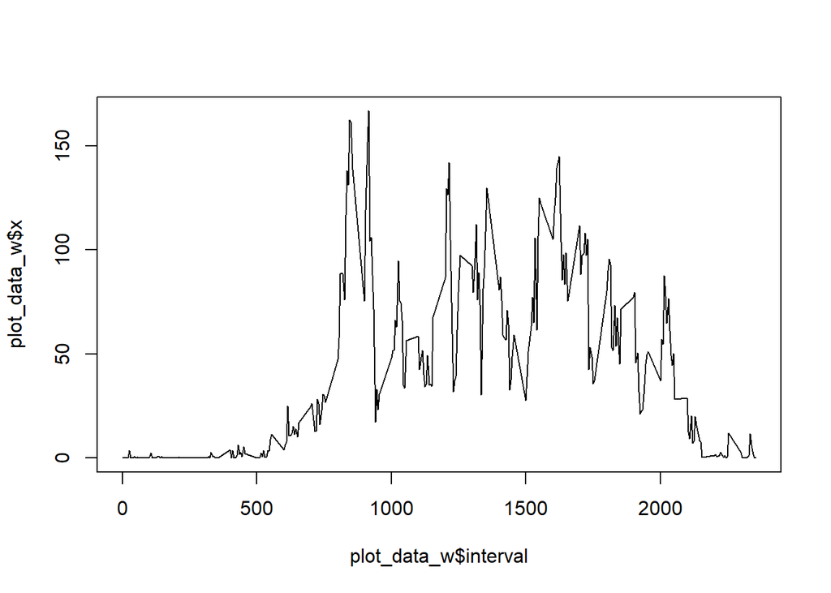

```r
plot(plot_data_w$interval,plot_data_w$x,type="l")
```

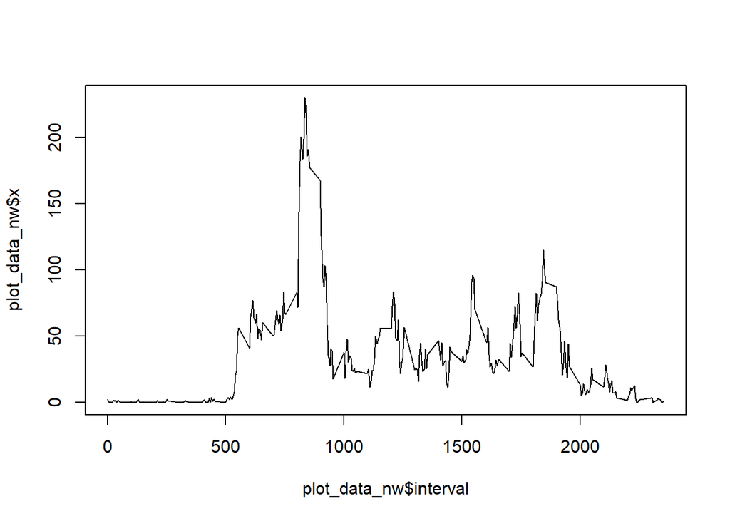

```r
plot(plot_data_nw$interval,plot_data_nw$x,type="l")
```